# Lab Six: CNNs

Members:  
CSE 5324:Shenxiao Mei, Samuel Lefcourt  
CSE 7324: Chenming Cui, Zeqi Guo

In this lab, we will use a dataset of images of hand gesture. There are 10 different gestures representing 0-9 numbers.Sign languages (also known as signed languages) are languages that use manual communication to convey meaning. This can include simultaneously employing hand gestures, movement, orientation of the fingers, arms or body, and facial expressions to convey a speaker's ideas. Since our dataset only contains the number digits sign from 0-9, we would consider our model can be used as a starting point for a mobile app which teaches people sign language. Users can take photos of their hand gesture and upload in the app, where our model will identify the hand gesture to see if it is correct. As a starting point of the recognization app, our model needs to perform very well in differentiating the digits sign in order to be useful.

In terms of standard of success, we need to compare our model accuracy in recognization with the real human sign interpreters. In **http://d-scholarship.pitt.edu/8488/1/SadlerKarenL20509.pdf**, there is a research conducted to find out the accuracy human interpreter in tranlating science words into signs in a science videos. The result shows that the interpretation are roughly 80% correct. Since our model only recognize digits,which is a lot easier task than translating science knowledge. Also, our accuracy needs to be very high in order to conduct future work, we set our standard to be 95% correct.

**Kaggle Source: https://www.kaggle.com/ardamavi/sign-language-digits-dataset**

## Load the data

```
(-0.5, 63.5, 63.5, -0.5)
```

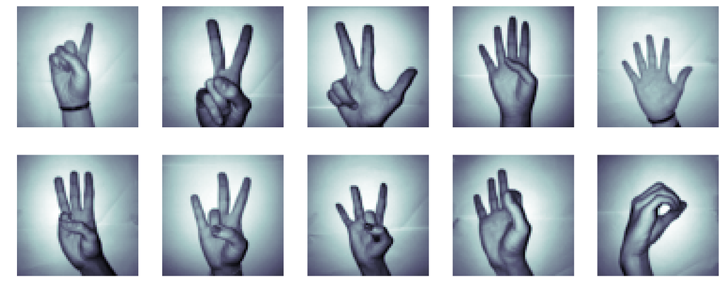

```python
import matplotlib.pyplot as plt
import numpy as np
import pandas as pd


# load data set
X = np.load('dataset/Sign-language-digits-dataset/X.npy')
y = np.load('dataset/Sign-language-digits-dataset/Y.npy')

img_size = 64
plt.subplots(2, 5, figsize=(20, 8))
plt.subplot(2, 5, 1)  #1
plt.imshow(X[1020].reshape(img_size, img_size), cmap='bone')
plt.axis('off')

plt.subplot(2, 5, 2)  #2
plt.imshow(X[1730].reshape(img_size, img_size), cmap='bone')
plt.axis('off')

plt.subplot(2, 5, 3)  #3
plt.imshow(X[1500].reshape(img_size, img_size), cmap='bone')
plt.axis('off')

plt.subplot(2, 5, 4)  #4
plt.imshow(X[1320].reshape(img_size, img_size), cmap='bone')
plt.axis('off')

plt.subplot(2, 5, 5)  #5
plt.imshow(X[1930].reshape(img_size, img_size), cmap='bone')
plt.axis('off')

plt.subplot(2, 5, 6)  #6
plt.imshow(X[620].reshape(img_size, img_size), cmap='bone')
plt.axis('off')

plt.subplot(2, 5, 7)  #7
plt.imshow(X[410].reshape(img_size, img_size), cmap='bone')
plt.axis('off')


plt.subplot(2, 5, 8)  #8
plt.imshow(X[1200].reshape(img_size, img_size), cmap='bone')
plt.axis('off')

plt.subplot(2, 5, 9)  #9
plt.imshow(X[0].reshape(img_size, img_size), cmap='bone')
plt.axis('off')

plt.subplot(2, 5, 10)  #0
plt.imshow(X[210].reshape(img_size, img_size), cmap='bone')
plt.axis('off')
```

## Metrics Selection

In this lab for our model we decide to use accuracy. Since our model will serve as a feasibility study of a hand gesture recognization app, and it only identify sign digits, accuracy can be used as a perfect metrics for us to know if the model performs well enough for the app developer to move on to the next stage (recognize character). We need to compare our model's accuracy to a professional interpreter's accuracy in order to determine whether our model is successful.

## Data Split

In our model we will use a stratified kfold cross validation. Since our dataset has only 2000 thousand samples for ten digits, 200 hundred images per digit, if we perform a normal 80/20 split, it is likely that we selected twenty percent of unrepresentative samples. We use 10 folds in our model because the amount of 10 is widely known as the optimal number of folds in machine learning.

```python
img_wh =  64
NUM_CLASSES = 10

# fix size
from sklearn.model_selection import StratifiedKFold
import keras

cv=StratifiedKFold(n_splits=10, shuffle=True)

X_train_list=[]
X_test_list=[]
y_train_list=[]
y_test_list=[]
y_train_ohe_list=[]
y_test_ohe_list=[]

label = []
for i in range(len(y)):
    label.append(np.argmax(y[i]))
y = np.asarray(label)

for train_index, test_index in cv.split(X, y):
#     print("TRAIN: ", train_index,"\n", "TEST: ", test_index, "\n")
    X_train, X_test = X[train_index], X[test_index]
    y_train, y_test = y[train_index], y[test_index]
    y_train_ohe = keras.utils.to_categorical(y_train, NUM_CLASSES)
    y_test_ohe = keras.utils.to_categorical(y_test, NUM_CLASSES)
    X_train = np.expand_dims(X_train.reshape((-1,img_wh,img_wh)), axis=3)
    X_test = np.expand_dims(X_test.reshape((-1,img_wh,img_wh)), axis=3)

    X_train_list.append(X_train)
    X_test_list.append(X_test)
    y_train_list.append(y_train)
    y_test_list.append(y_test)
    y_train_ohe_list.append(y_train_ohe)
    y_test_ohe_list.append(y_test_ohe)
```

## Data Expansion

Since we are using kfold cross validation methods, it is better to create a function that will return a new ImageDataGenerator object to fit with new data every time.

In our data expansion, we will use rotation_range. In our business case, when people do hand gesture, it is very likely they don't have the perfect angle, having rotation should help with our training. We are use width shift and height shift just in case the hand gesture may have shifts in the location.

Overall, since each hand gesture has only 200 images, we use data generator not only to reduce the noise of shifts and rotation, we can reduce the chance of overfitting.

```python
import keras
from keras.preprocessing.image import ImageDataGenerator

def get_datagen():
    datagen = ImageDataGenerator(featurewise_center=False,
        samplewise_center=False,
        featurewise_std_normalization=False,
        samplewise_std_normalization=False,
        zca_whitening=False,
        rotation_range=5, # used, Int. Degree range for random rotations.
        width_shift_range=0.1, # used, Float (fraction of total width). Range for random horizontal shifts.
        height_shift_range=0.1, # used,  Float (fraction of total height). Range for random vertical shifts.
        shear_range=0., # Float. Shear Intensity (Shear angle in counter-clockwise direction as radians)
        zoom_range=0.,
        channel_shift_range=0.,
        fill_mode='nearest',
        cval=0.,
        horizontal_flip=True,
        vertical_flip=False,
        rescale=None)
    return datagen
```

## Modeling

For modeling, since we have 10 folds for each model, we will create two lists which store the y prediction and histories for future analysis

### CNN Model 1

For the first Model, we will use two convolutional layers in which the filter number is same. In each convolutional layer we will use a three by three kernel, a relu activation function and a max pooling. Then it will pass through a fallten layer and two layer of 100 perceptrons.

```python
from keras.models import Sequential
from keras.layers import Dense, Dropout, Activation
from keras.optimizers import SGD
from keras.layers import Dense,Flatten,Dropout,Concatenate,GlobalAveragePooling2D,Lambda,ZeroPadding2D
from keras.layers import SeparableConv2D,BatchNormalization,MaxPooling2D,Conv2D

cnn1 = Sequential()

num_filt_layers = [24, 24]
for num_filters in num_filt_layers:
    cnn1.add(Conv2D(filters=num_filters,
                   input_shape=(64, 64, 1),
                   kernel_size=(3,3),
                   padding='same',
                   activation='relu'))
    cnn1.add(Activation('relu'))
    cnn1.add(MaxPooling2D(pool_size=(2, 2), data_format="channels_first"))


# add one layer on flattened output
cnn1.add(Flatten())
cnn1.add(Dense(100, activation='relu'))
cnn1.add(Dense(100, activation='relu'))
cnn1.add(Dense(10, activation='softmax'))

# Let's train the model
cnn1.compile(loss='categorical_crossentropy',
              optimizer='rmsprop',
              metrics=['accuracy'])
```

```python
import keras.backend as K
def reset_weights(model):
    session = K.get_session()
    for layer in model.layers:
        if hasattr(layer, 'kernel_initializer'):
            layer.kernel.initializer.run(session=session)
```

```python
%%time

y_pred_cnn1_list=[]
history_cnn1_list=[]
for i in range(len(X_train_list)):
    datagen_1=get_datagen()
    history=cnn1.fit_generator(datagen_1.flow(X_train_list[i], y_train_ohe_list[i], batch_size=32),
                             steps_per_epoch=int(X_train_list[i].shape[0]/64),
                             epochs=80, verbose=1,
                               validation_data=(X_test_list[i], y_test_ohe_list[i])
                             )
    y_pred_cnn1 = cnn1.predict(X_test_list[i]).ravel()
    y_pred_cnn1_list.append(y_pred_cnn1)
    history_cnn1_list.append(history)
    reset_weights(cnn1)
```

```
CPU times: user 9min 11s, sys: 25.7 s, total: 9min 37s
Wall time: 6min 35s
```

### CNN Model 2

In the CNN model, we did a slight change on parameters on the convultional layer. We change the kernel size to 2x2.

```python
cnn2 = Sequential()

num_filt_layers = [24, 24]
for num_filters in num_filt_layers:
    cnn2.add(Conv2D(filters=num_filters,
                   input_shape=(64, 64, 1),
                   kernel_size=(2,2),
                   padding='same',
                   activation='relu'))
    cnn2.add(Activation('relu'))
    cnn2.add(MaxPooling2D(pool_size=(2, 2), data_format="channels_first"))


# add one layer on flattened output
cnn2.add(Flatten())
cnn2.add(Dense(100, activation='relu'))
cnn2.add(Dense(100, activation='relu'))
cnn2.add(Dense(10, activation='softmax'))

# Let's train the model
cnn2.compile(loss='categorical_crossentropy',
              optimizer='rmsprop',
              metrics=['accuracy'])
```

```python
%%time

y_pred_cnn2_list=[]
history_cnn2_list=[]
for i in range(len(X_train_list)):
    datagen_2=get_datagen()
    history=cnn2.fit_generator(datagen_2.flow(X_train_list[i], y_train_ohe_list[i], batch_size=32),
                             steps_per_epoch=int(X_train_list[i].shape[0]/64),
                             epochs=80, verbose=1,
                               validation_data=(X_test_list[i], y_test_ohe_list[i])
                             )
    y_pred_cnn2 = cnn2.predict(X_test_list[i]).ravel()
    y_pred_cnn2_list.append(y_pred_cnn2)
    history_cnn2_list.append(history)
    reset_weights(cnn2)
```

### CNN Model 3

This model's prototype is Model 1, but in this model, we change the filter to three and the filter number

```python
cnn3 = Sequential()

num_filt_layers = [24, 32, 48]
for num_filters in num_filt_layers:
    cnn3.add(Conv2D(filters=num_filters,
                   input_shape=(64, 64, 1),
                   kernel_size=(3,3),
                   padding='same',
                   activation='relu'))
    cnn3.add(Activation('relu'))
    cnn3.add(MaxPooling2D(pool_size=(2, 2), data_format="channels_first"))


# add one layer on flattened output
cnn3.add(Flatten())
cnn3.add(Dense(100, activation='relu'))
cnn3.add(Dense(100, activation='relu'))
cnn3.add(Dense(10, activation='softmax'))

# Let's train the model
cnn3.compile(loss='categorical_crossentropy',
              optimizer='rmsprop',
              metrics=['accuracy'])
```

```python
%%time

y_pred_cnn3_list=[]
history_cnn3_list=[]
for i in range(len(X_train_list)):
    datagen_3=get_datagen()
    history=cnn3.fit_generator(datagen_3.flow(X_train_list[i], y_train_ohe_list[i], batch_size=32),
                             steps_per_epoch=int(X_train_list[i].shape[0]/64),
                             epochs=80, verbose=1,
                               validation_data=(X_test_list[i], y_test_ohe_list[i])
                             )
    y_pred_cnn3 = cnn3.predict(X_test_list[i]).ravel()
    y_pred_cnn3_list.append(y_pred_cnn3)
    history_cnn3_list.append(history)
    reset_weights(cnn3)
```

```
Wall time: 1h 54min 39s
```

### CNN Model 4

```python
cnn4 = Sequential()

num_filt_layers = [24, 32, 48]
for num_filters in num_filt_layers:
    cnn4.add(Conv2D(filters=num_filters,
                   input_shape=(64, 64, 1),
                   kernel_size=(3,3),
                   padding='same',
                   activation='relu'))
    cnn4.add(Activation('relu'))
    cnn4.add(MaxPooling2D(pool_size=(2, 2), data_format="channels_first"))


# add one layer on flattened output
cnn4.add(Flatten())
cnn4.add(Dense(100, activation='relu'))
cnn4.add(Dense(100, activation='relu'))
cnn4.add(Dense(10, activation='softmax'))

# Let's train the model
cnn4.compile(loss='mean_squared_error',
              optimizer='rmsprop',
              metrics=['accuracy'])
```

```python
%%time

y_pred_cnn4_list=[]
history_cnn4_list=[]
for i in range(len(X_train_list)):
    datagen_4=get_datagen()
    history=cnn4.fit_generator(datagen_4.flow(X_train_list[i], y_train_ohe_list[i], batch_size=32),
                             steps_per_epoch=int(X_train_list[i].shape[0]/64),
                             epochs=80, verbose=1,
                               validation_data=(X_test_list[i], y_test_ohe_list[i])
                             )
    y_pred_cnn4 = cnn4.predict(X_test_list[i]).ravel()
    y_pred_cnn4_list.append(y_pred_cnn4)
    history_cnn4_list.append(history)
    reset_weights(cnn4)
```

```
Wall time: 1h 42min 18s
```

## Accuracy score history - - Training vs Validation

```python
history1_val_acc=np.zeros(80)
history2_val_acc=np.zeros(80)
history3_val_acc=np.zeros(80)
history4_val_acc=np.zeros(80)
history1_acc=np.zeros(80)
history2_acc=np.zeros(80)
history3_acc=np.zeros(80)
history4_acc=np.zeros(80)
history1_val_acc_loss=np.zeros(80)
history2_val_acc_loss=np.zeros(80)
history3_val_acc_loss=np.zeros(80)
history4_val_acc_loss=np.zeros(80)
history1_acc_loss=np.zeros(80)
history2_acc_loss=np.zeros(80)
history3_acc_loss=np.zeros(80)
history4_acc_loss=np.zeros(80)
for i in range(10):
    history1_val_acc+=np.array(history_cnn1_list[i].history['val_acc'])
    history2_val_acc+=np.array(history_cnn2_list[i].history['val_acc'])
    history3_val_acc+=np.array(history_cnn3_list[i].history['val_acc'])
    history4_val_acc+=np.array(history_cnn4_list[i].history['val_acc'])
history1_val_acc/=10
history2_val_acc/=10
history3_val_acc/=10
history4_val_acc/=10

for i in range(10):
    history1_acc+=np.array(history_cnn1_list[i].history['acc'])
    history2_acc+=np.array(history_cnn2_list[i].history['acc'])
    history3_acc+=np.array(history_cnn3_list[i].history['acc'])
    history4_acc+=np.array(history_cnn4_list[i].history['acc'])
history1_acc/=10
history2_acc/=10
history3_acc/=10
history4_acc/=10

for i in range(10):
    history1_acc_loss+=np.array(history_cnn1_list[i].history['loss'])
    history2_acc_loss+=np.array(history_cnn2_list[i].history['loss'])
    history3_acc_loss+=np.array(history_cnn3_list[i].history['loss'])
    history4_acc_loss+=np.array(history_cnn4_list[i].history['loss'])
history1_acc_loss/=10
history2_acc_loss/=10
history3_acc_loss/=10
history4_acc_loss/=10

for i in range(10):
    history1_val_acc_loss+=np.array(history_cnn1_list[i].history['val_loss'])
    history2_val_acc_loss+=np.array(history_cnn2_list[i].history['val_loss'])
    history3_val_acc_loss+=np.array(history_cnn3_list[i].history['val_loss'])
    history4_val_acc_loss+=np.array(history_cnn4_list[i].history['val_loss'])
history1_val_acc_loss/=10
history2_val_acc_loss/=10
history3_val_acc_loss/=10
history4_val_acc_loss/=10
print(history2_val_acc)
%matplotlib inline
```

[output not shown]

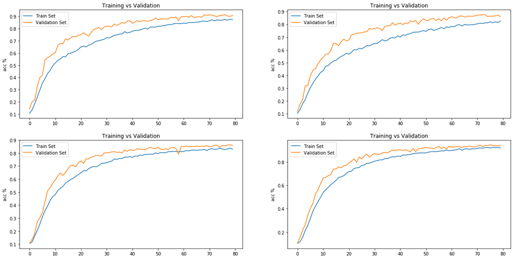

```python
%matplotlib inline


plt.figure(figsize=(20,10))
plt.subplot(2, 2, 1)
plt.plot(history1_acc, label='Train Set')
plt.ylabel('acc %')
plt.title('Training vs Validation')
plt.plot(history1_val_acc, label='Validation Set')
plt.legend()


plt.subplot(2, 2, 2)
plt.plot(history2_acc, label='Train Set')
plt.ylabel('acc %')
plt.title('Training vs Validation')
plt.plot(history2_val_acc, label='Validation Set')
plt.legend()


plt.subplot(2, 2, 3)
plt.plot(history3_acc, label='Train Set')
plt.ylabel('acc %')
plt.title('Training vs Validation')
plt.plot(history3_val_acc, label='Validation Set')
plt.legend()


plt.subplot(2, 2, 4)
plt.plot(history4_acc, label='Train Set')
plt.ylabel('acc %')
plt.title('Training vs Validation')
plt.plot(history4_val_acc, label='Validation Set')
plt.legend()
```

Model 1: 2 filter layer; 3x3 kernel

Model 2: 2 filter layer; 2x2 kernel

Model 3: 3 filter layer; 3x3 kernel

All models' accuracies and losses become stable after epoch 60. We did 80 epoches in total for each fold, so for the last 20 epoches the accuracies just bounce up and down.

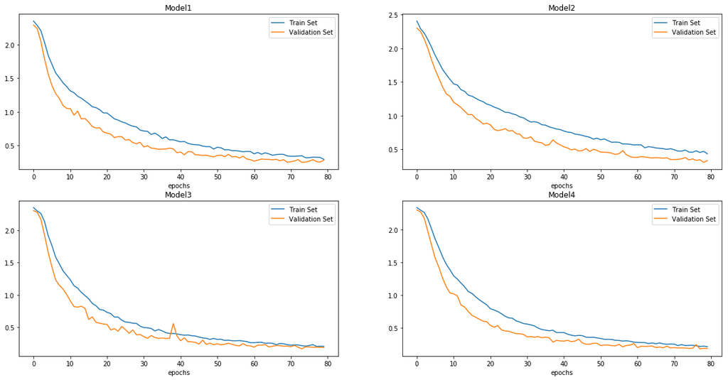

```python
%matplotlib inline

plt.figure(figsize=(20,10))
plt.subplot(2, 2, 1)

plt.plot(history1_acc_loss,label='Train Set')
plt.legend()
plt.title('Model1')
plt.xlabel('epochs')
plt.plot(history1_val_acc_loss, label='Validation Set')
plt.legend()

plt.subplot(2, 2, 2)
plt.plot(history2_acc_loss,label='Train Set')
plt.legend()
plt.title('Model2')
plt.xlabel('epochs')
plt.plot(history2_val_acc_loss, label='Validation Set')
plt.legend()

plt.subplot(2, 2, 3)
plt.plot(history3_acc_loss,label='Train Set')
plt.legend()
plt.title('Model3')
plt.xlabel('epochs')
plt.plot(history3_val_acc_loss, label='Validation Set')
plt.legend()

plt.subplot(2, 2, 4)
plt.plot(history4_acc_loss,label='Train Set')
plt.legend()
plt.title('Model4')
plt.xlabel('epochs')
plt.plot(history4_val_acc_loss, label='Validation Set')
plt.legend()
```

## Fight with MLP

```python
mlp = Sequential()
mlp.add( Dense(input_dim=64*64, units=100, activation='relu') )
mlp.add( Dense(units=50, activation='relu') )
mlp.add( Dense(units=50, activation='relu') )
mlp.add( Dense(NUM_CLASSES) )
mlp.add( Activation('softmax') )

mlp.compile(loss='categorical_crossentropy',
              optimizer='rmsprop',
              metrics=['accuracy'])



y_pred_mlp_list=[]
for i in range(len(X_train_list)):
    X_train_alt=X_train_list[i].reshape(X_train_list[i].shape[0],64*64)
    X_test_alt=X_test_list[i].reshape(X_test_list[i].shape[0],64*64)

    datagen_5=get_datagen()
    mlp.fit(X_train_alt, y_train_ohe_list[i],
        batch_size=32, epochs=80,
        shuffle=True, verbose=1,
       validation_data=(X_test_alt, y_test_ohe_list[i]))
    y_pred_mlp = mlp.predict(X_test_list[i].reshape(X_test_list[i].shape[0],64*64)).ravel()
    y_pred_mlp_list.append(y_pred_mlp)
    reset_weights(mlp)
```

```
Train on 1852 samples, validate on 210 samples
Train on 1852 samples, validate on 210 samples
Train on 1852 samples, validate on 210 samples
Train on 1852 samples, validate on 210 samples
Train on 1853 samples, validate on 209 samples
Train on 1854 samples, validate on 208 samples
Train on 1858 samples, validate on 204 samples
Train on 1861 samples, validate on 201 samples
Train on 1862 samples, validate on 200 samples
Train on 1862 samples, validate on 200 samples
```

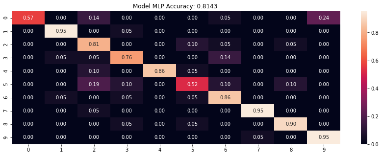

```python
plt.figure(figsize=(15,5))
yhat=y_pred_mlp_list[0].reshape(210,10)
yhat = np.argmax(yhat, axis=1)
for i in range(1,10):
    yhat_conc=y_pred_mlp_list[i].reshape(210,10)
    yhat_conc = np.argmax(yhat_conc, axis=1)
    yhat=np.concatenate((yhat,yhat_conc), axis=0)
acc = mt.accuracy_score(y_test_list,yhat)
cm = mt.confusion_matrix(y_test_list,yhat)
cm = cm/np.sum(cm,axis=1)[:,np.newaxis]
sns.heatmap(cm, annot=True, fmt='.2f')
plt.title('Model MLP'+' Accuracy: {:.4f} '.format(acc))
```

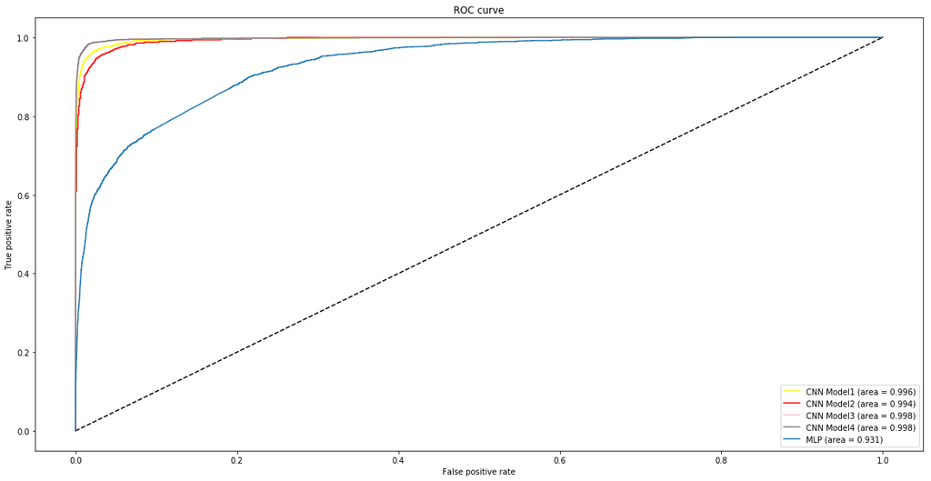

```python
y_10_fold=np.zeros(len(y_test_ohe_list[0].flatten()))
y_pred_cnn1=np.zeros(len(y_pred_cnn1_list[0]))
y_pred_cnn2=np.zeros(len(y_pred_cnn2_list[0]))
y_pred_cnn3=np.zeros(len(y_pred_cnn3_list[0]))
y_pred_cnn4=np.zeros(len(y_pred_cnn4_list[0]))
y_pred_mlp=np.zeros(len(y_pred_mlp_list[0]))
for i in range(10):
    y_pred_cnn1=np.concatenate((y_pred_cnn1,y_pred_cnn1_list[i]), axis=0)
    y_pred_cnn2=np.concatenate((y_pred_cnn2,y_pred_cnn2_list[i]), axis=0)
    y_pred_cnn3=np.concatenate((y_pred_cnn3,y_pred_cnn3_list[i]), axis=0)
    y_pred_cnn4=np.concatenate((y_pred_cnn4,y_pred_cnn4_list[i]), axis=0)
    y_pred_mlp=np.concatenate((y_pred_mlp,y_pred_mlp_list[i]), axis=0)
    y_10_fold=np.concatenate((y_10_fold,y_test_ohe_list[i].flatten()),axis=0)

from matplotlib import pyplot as plt
from sklearn.metrics import roc_curve

plt.figure(figsize=(20,10))

color = ['yellow', 'red', 'pink','grey','purple']

# for_roc=y_test_ohe.flatten()
# y_pred_keras_1 = cnn1.predict(X_test).ravel()
fpr_keras_1, tpr_keras_1, thresholds_keras = roc_curve(y_10_fold, y_pred_cnn1)
fpr_keras_2, tpr_keras_2, thresholds_keras = roc_curve(y_10_fold, y_pred_cnn2)
fpr_keras_3, tpr_keras_3, thresholds_keras = roc_curve(y_10_fold, y_pred_cnn3)
fpr_keras_4, tpr_keras_4, thresholds_keras = roc_curve(y_10_fold, y_pred_cnn4)
fpr_mlp, tpr_mlp, thresholds_mlp = roc_curve(y_10_fold, y_pred_mlp)


from sklearn.metrics import auc
auc_keras_1 = auc(fpr_keras_1, tpr_keras_1)
auc_keras_2 = auc(fpr_keras_2, tpr_keras_2)
auc_keras_3 = auc(fpr_keras_3, tpr_keras_3)
auc_keras_4 = auc(fpr_keras_4, tpr_keras_4)


auc_mlp = auc(fpr_mlp, tpr_mlp)

i=0
plt.plot([0, 1], [0, 1], 'k--')
plt.plot(fpr_keras_1, tpr_keras_1, label='CNN Model1 (area = {:.3f})'.format(auc_keras_1),color=color[i])
i+=1
plt.plot(fpr_keras_2, tpr_keras_2, label='CNN Model2 (area = {:.3f})'.format(auc_keras_2),color=color[i])
i+=1
plt.plot(fpr_keras_3, tpr_keras_3, label='CNN Model3 (area = {:.3f})'.format(auc_keras_3),color=color[i])
i+=1
plt.plot(fpr_keras_4, tpr_keras_4, label='CNN Model4 (area = {:.3f})'.format(auc_keras_4),color=color[i])

plt.plot(fpr_mlp, tpr_mlp, label='MLP (area = {:.3f})'.format(auc_mlp))

plt.xlabel('False positive rate')
plt.ylabel('True positive rate')
plt.title('ROC curve')
plt.legend(loc='best')
plt.show()
```

## Visualize the final results of the CNNs and interpret the performance.

We use the t-distribution with 95% confidence, we will then check if the range of their difference cover 0, if it cover zero, we cannot say they are statisitically different from one and another

```
 								HeatMap from Model1 to Model4
```

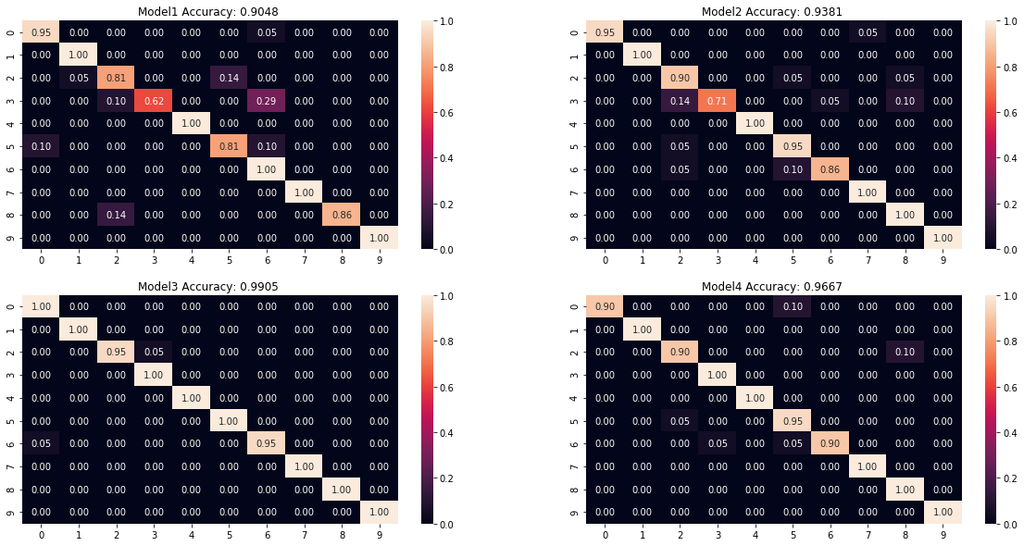

```python
from sklearn import metrics as mt
from skimage.io import imshow
import seaborn as sns

%matplotlib inline


plt.figure(figsize=(20,10))
plt.subplot(2, 2, 1)
yhat=y_pred_cnn1_list[0].reshape(210,10)
yhat = np.argmax(yhat, axis=1)
for i in range(1,10):
    yhat_conc = y_pred_cnn1_list[i].reshape(210,10)
    yhat_conc = np.argmax(yhat_conc, axis=1)
    yhat=np.concatenate((yhat,yhat_conc), axis=0)
acc = mt.accuracy_score(y_test_list,yhat)
cm = mt.confusion_matrix(y_test_list,yhat)
cm = cm/np.sum(cm,axis=1)[:,np.newaxis]
sns.heatmap(cm, annot=True, fmt='.2f')
plt.title('Model1'+' Accuracy: {:.4f} '.format(acc))


plt.subplot(2, 2, 2)
yhat=y_pred_cnn2_list[0].reshape(210,10)
yhat = np.argmax(yhat, axis=1)
for i in range(1,10):
    yhat_conc = y_pred_cnn2_list[i].reshape(210,10)
    yhat_conc = np.argmax(yhat_conc, axis=1)
    yhat=np.concatenate((yhat,yhat_conc), axis=0)
acc = mt.accuracy_score(y_test_list,yhat)
cm = mt.confusion_matrix(y_test_list,yhat)
cm = cm/np.sum(cm,axis=1)[:,np.newaxis]
sns.heatmap(cm, annot=True, fmt='.2f')
plt.title('Model2'+' Accuracy: {:.4f} '.format(acc))

plt.subplot(2, 2, 3)
yhat=y_pred_cnn3_list[0].reshape(210,10)
yhat = np.argmax(yhat, axis=1)
for i in range(1,10):
    yhat_conc = y_pred_cnn3_list[i].reshape(210,10)
    yhat_conc = np.argmax(yhat_conc, axis=1)
    yhat=np.concatenate((yhat,yhat_conc), axis=0)
acc = mt.accuracy_score(y_test_list,yhat)
cm = mt.confusion_matrix(y_test_list,yhat)
cm = cm/np.sum(cm,axis=1)[:,np.newaxis]
sns.heatmap(cm, annot=True, fmt='.2f')
plt.title('Model3'+' Accuracy: {:.4f} '.format(acc))

plt.subplot(2, 2, 4)
yhat = y_pred_cnn4_list[0].reshape(210,10)
yhat = np.argmax(yhat, axis=1)
for i in range(1,10):
    yhat_conc = y_pred_cnn4_list[i].reshape(210,10)
    yhat_conc = np.argmax(yhat_conc, axis=1)
    yhat=np.concatenate((yhat,yhat_conc), axis=0)
acc = mt.accuracy_score(y_test_list,yhat)
cm = mt.confusion_matrix(y_test_list,yhat)
cm = cm/np.sum(cm,axis=1)[:,np.newaxis]
sns.heatmap(cm, annot=True, fmt='.2f')
plt.title('Model4'+' Accuracy: {:.4f} '.format(acc))
print(' \t\t\t\t\t\t\t\tHeatMap from Model1 to Model4')
```

From the heat map we see that model 1 and model 2 have trouble identifying the number '3', that is because all signs of 3,6,7,8,9 have three fingers but different combination of thumbs. Model 3 and model 4 perform uniformly well on all classes.

```python
t=2.26/np.sqrt(10)
e1=(1-y_pred_cnn1)-(1-y_pred_cnn2)
stdtot1=np.std(e1)
dbar1=np.mean(e1)
print('Between Model 1 and Model 2: ''range is',dbar1-t*stdtot1,dbar1+t*stdtot1)

e2=(1-y_pred_cnn1)-(1-y_pred_cnn3)
stdtot2=np.std(e2)
dbar2=np.mean(e2)
print('Between Model 1 and Model 3: ''range is',dbar2-t*stdtot2,dbar2+t*stdtot2)

e3=(1-y_pred_cnn1)-(1-y_pred_cnn4)
stdtot3=np.std(e3)
dbar3=np.mean(e3)
print('Between Model 1 and Model 4: ''range is',dbar3-t*stdtot3,dbar3+t*stdtot3)

e4=(1-y_pred_cnn2)-(1-y_pred_cnn3)
stdtot4=np.std(e4)
dbar4=np.mean(e4)
print('Between Model 2 and Model 3: ''range is',dbar4-t*stdtot4,dbar4+t*stdtot4)

e5=(1-y_pred_cnn2)-(1-y_pred_cnn4)
stdtot5=np.std(e5)
dbar5=np.mean(e5)
print('Between Model 2 and Model 4: ''range is',dbar5-t*stdtot5,dbar5+t*stdtot5)

e6=(1-y_pred_cnn3)-(1-y_pred_cnn4)
stdtot6=np.std(e6)
dbar6=np.mean(e6)
print('Between Model 3 and Model 4: ''range is',dbar6-t*stdtot6,dbar6+t*stdtot6)

# print(2*t*stdtot1)
# print(2*t*stdtot2)
# print(2*t*stdtot3)
```

```
Between Model 1 and Model 2: range is -0.07725162813319145 0.0772516279476047
Between Model 1 and Model 3: range is -0.08847942542592191 0.08847942648631926
Between Model 1 and Model 4: range is -0.07038371875392295 0.07038371973644501
Between Model 2 and Model 3: range is -0.09335807989844946 0.09335808114443359
Between Model 2 and Model 4: range is -0.0847428656664999 0.0847428668346087
Between Model 3 and Model 4: range is -0.08243207639682083 0.08243207631894554
```

All the results ranges include 0, that means we cannot say these models are different from one and another.